# sparrpowR: Power Analysis to Detect Spatial Relative Risk Clusters

Ian D. Buller (GitHub: @idblr)

2025-08-28

Start with the necessary packages and seed for the vignette.

```r
loadedPackages <- c("geojsonsf", "ggmap", "ggplot2", "graphics", "grDevices", "sf", "sparrpowR", "spatstat", "terra", "tidyterra")
invisible(lapply(loadedPackages, library, character.only = TRUE))
set.seed(1234) # for reproducibility
```

Import data from Open Data DC [website](https://opendata.dc.gov/datasets/washington-dc-boundary).

```r
# Washington, D.C. boundary
gis_path1 <- "https://opendata.arcgis.com/datasets/7241f6d500b44288ad983f0942b39663_10.geojson"
dc <- geojson_sf(gis_path1)

# American Community Survey 2020 Census Tracts
gis_path2 <- "https://opendata.arcgis.com/datasets/95f1885eff9a4c089012a872c851c50a_8.geojson"
census <- geojson_sf(gis_path2)
```

We want to create a realistic boundary (i.e., polygon) of our study area. We are going to spatially clip our DC boundary by the census tracts in an attempt to remove major bodies of water where people do not reside.

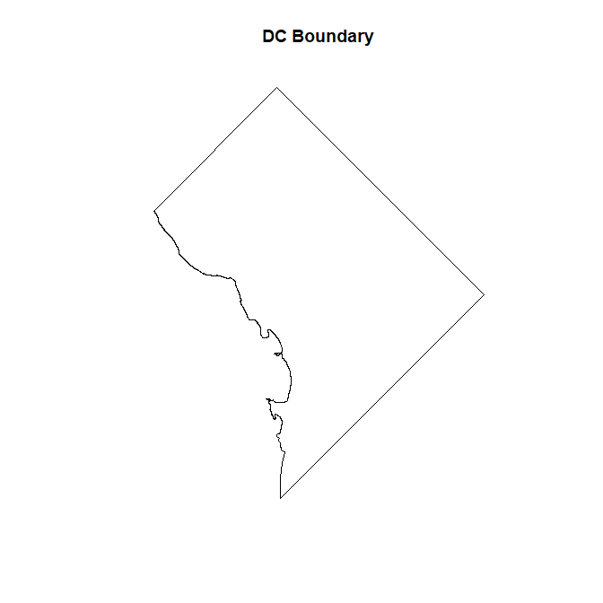

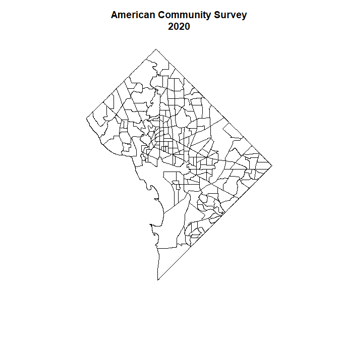

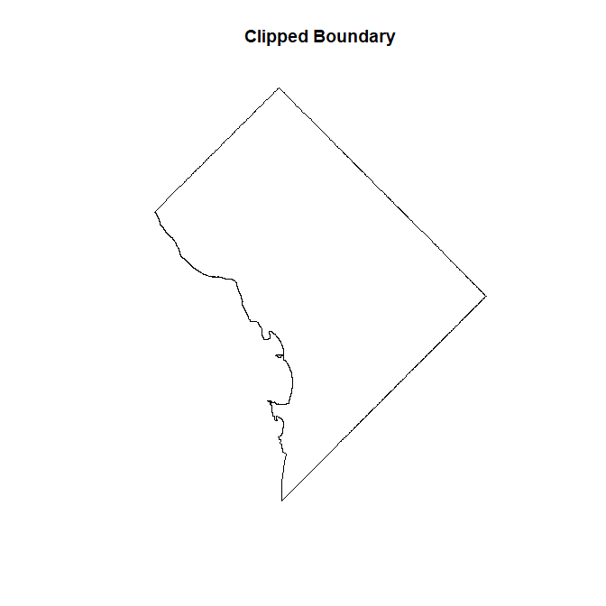

```r
clipwin <- st_union(census)
dcc <- st_intersection(dc, clipwin)
# Plot
plot(st_geometry(dc), main = "DC Boundary")
plot(st_geometry(census),  main = "American Community Survey\n2020")
plot(st_geometry(dcc), main = "Clipped Boundary")
```

```r
dcp <- st_transform(st_as_sf(dcc), crs = st_crs(32618))
dco <- as.owin(st_geometry(dcp))
```

In this hypothetical example, we want to estimate the local power of detecting a spatial case cluster relative to control locations. Study participants that tested positive for a disease (i.e., cases) are hypothesized to be located in a circular area around the Navy Yard, an Environmental Protection Agency (EPA) Superfund Site [(see the success story)](https://cumulis.epa.gov/supercpad/cursites/csitinfo.cfm?id=0300031).

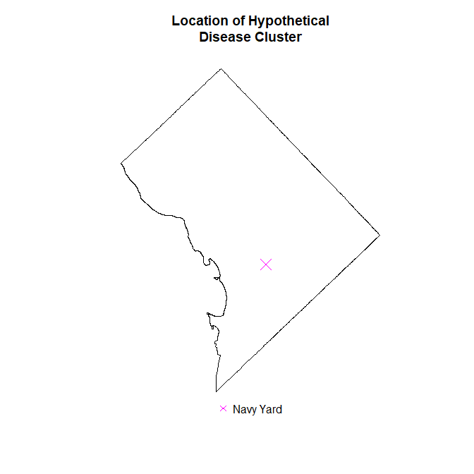

```r
navy <- data.frame(lon = 326414.70444451, lat = 4304571.1539442)
spf <- st_as_sf(navy, coords = c("lon", "lat"), crs = st_crs(32618))
# Plot
plot(st_geometry(dcp), main = "Location of Hypothetical\nDisease Cluster")
plot(spf, col = "magenta", add = T, pch = 4, cex = 2)
legend("bottom", xpd = T, y.intersp = -1.5, legend = c("Navy Yard"), col = "magenta", pch = 4, cex = 1, bty = "n")
```

We will assume that approximately 50 cases (e.g., `n_case = 50`) were clustered around the center of the Navy Yard (e.g., `samp_case = "MVN"`) with more cases near the center and fewer cases about 1 kilometers away (e.g., `s_case = 1000`).

If we were to conduct a study, where would we be sufficiently statistically powered to detect this spatial case cluster? To answer this question we will randomly sample approximately 950 participants (e.g., `n_conrol = 950` or 5% disease prevalence) around the Navy Yard (e.g., `samp_control = "MVN"`) sampling more participants near the center and fewer participants about 2 kilometers away (e.g., `s_control = 2000`). These participants would test negative for a disease (i.e., controls) were we to conduct a study. We can then resample control locations iteratively, as if we conducted the same study multiple times (e.g., `sim_total = 100`). We can conclude that we are sufficiently powered to detect a spatial clustering in areas where a statistically significant spatial case cluster was located in at least 80% (e.g., `p_thresh = 0.8`) of these theoretical studies. The `spatial_power()` function calculates both a one-tailed, lower tailed hypothesis (i.e., case clustering only) and a two-tailed hypothesis (i.e., case and control clustering). Use the `cascon` argument in the `spatial_plots()` function to plot either test.

```r
start_time <- Sys.time() # record start time
sim_power <- spatial_power(
  x_case = navy[[1]], y_case = navy[[2]], # center of cluster
  x_control = navy[[1]], y_control = navy[[2]], # center of cluster
  n_case = 50, n_control = 950, # sample size of case/control
  samp_case = "MVN", samp_control = "MVN", # samplers
  s_case = 1000, s_control = 2000, # approximate size of clusters
  alpha = 0.05, # critical p-value
  sim_total = 100, # number of iterations
  win = dco, # study area
  resolution = 100, # number gridded knots on x-axis
  edge = "diggle", # correct for edge effects
  adapt = FALSE, # fixed-bandwidth
  h0 = NULL, # automatically select bandwidth for each iteration
  verbose = FALSE # no printout
)
end_time <- Sys.time() # record end time
time_srr <- end_time - start_time # Calculate run time
```

We plot the statistical power for a one-tailed, lower-tail hypothesis (`cascon = FALSE`) at `alpha = 0.05` using the `spatial_plots()` function.

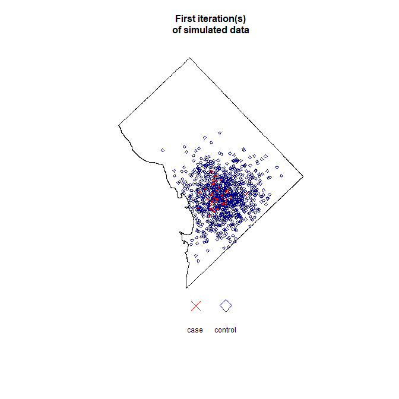

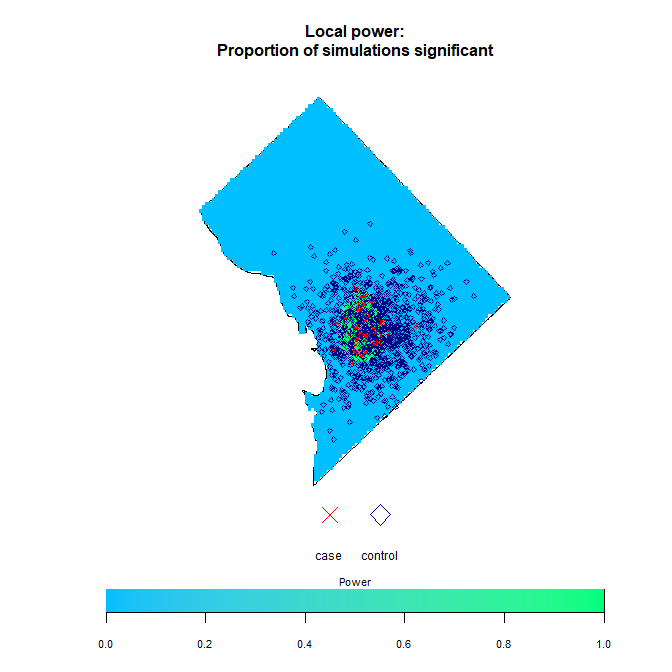

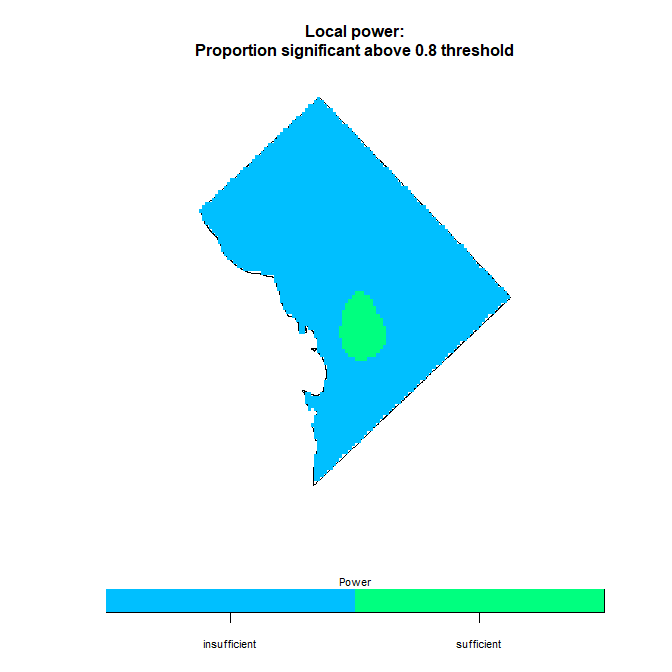

```r
cols <- c("deepskyblue", "springgreen", "red", "navyblue") # colors for plots
chars <- c(4,5) # symbols for point-locations
sizes <- c(0.5,0.5) # size of point-locations
p_thresh <- 0.8 # 80% of iterations with statistically significant results

## Data Visualization of Input and Power
spatial_plots(
  input = sim_power, # use output of above simulation
  p_thresh = p_thresh, # power cut-off
  cascon = FALSE, # one-tail, lower tail hypothesis test (i.e., case clustering)
  plot_pts = TRUE, # display the points in the second plot
  chars = chars, # case, control
  sizes = sizes, # case, control
  cols = cols # colors of plot
)
```

Now, lets overlay our results on top of a basemap. Here, we will use an open-source map from [Stamen](https://stamen.com/open-source/), that is unprojected in WGS84. We extract the rectangular box (i.e., bounding box) surrounding our polygon boundary of the District of Columbia (WGS84).

```r
dcbb <- st_bbox(st_buffer(st_as_sf(dc), dist = 0.015))
dcbbm <- matrix(dcbb, nrow = 2)
base_map <- get_stadiamap(bbox = dcbbm, maptype = "stamen_terrain")
```

Prepare the points from the first simulation for plotting in ggplot2 suite and prepare the original boundary for plotting in ggplot2 suite.

```r
sim_pts <- sim_power$sim  # extract points from first iteration
sim_pts <- st_as_sf(sim_pts) # convert to simple features
names(sim_pts)[1] <- "mark"
st_crs(sim_pts) <- st_crs(32618)
sim_pts_wgs84 <-  st_transform(sim_pts, crs = st_crs(4326)) # project to basemap
```

Prepare the SpatRaster from the simulation for plotting in ggplot2 suite.

```r
pvalprop <- data.frame(
  x = sim_power$rx,
  y = sim_power$ry,
  z = sim_power$pval_prop_cas
) # extract proportion significant
lrr_narm <- na.omit(pvalprop) # remove NAs
pvalprop_raster <- rast(lrr_narm) # convert to SpatRaster
rm(pvalprop, lrr_narm) # conserve memory
crs(pvalprop_raster) <- crs(dcp) # set output project (UTM 18N)
pvalprop_raster <- project(pvalprop_raster, dc) # unproject (WGS84)
rampcols <- colorRampPalette(colors = c(cols[1], cols[2]), space="Lab")(length(values(pvalprop_raster))) # set colorramp
```

Plot local power as a continuous outcome with point-locations using the ggplot2 suite.

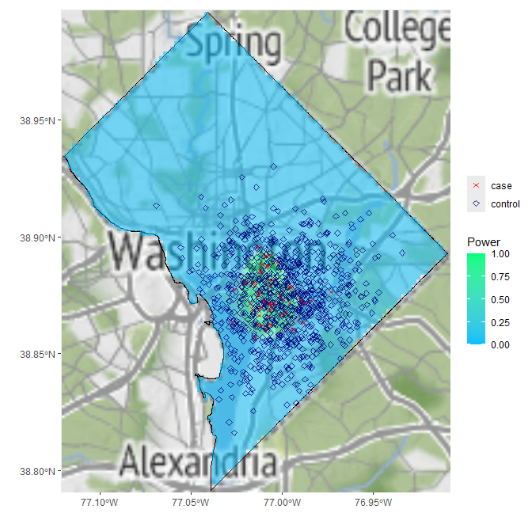

```r
ggmap(base_map) + # basemap
  geom_sf(
    data = dcc, # original boundary
    fill = "transparent",
    colour = "black",
    inherit.aes = FALSE
  ) +
  geom_spatraster(
    data = pvalprop_raster, # output SpatRaster
    size = 0,
    alpha = 0.5
  ) +
  scale_fill_gradientn(colours = rampcols, na.value = NA) + # colors for SpatRaster
  geom_sf(
    data = sim_pts_wgs84[-1, ], # simulated point-locations
    aes(color = mark, shape = mark),
    alpha = 0.8,
    inherit.aes = FALSE
  ) +
  scale_color_manual(values = cols[3:4]) + # fill of point-locations
  scale_shape_manual(values = chars) + # shape of point-locations
  labs(x = "", y = "", fill = "Power", color = "", shape = "") # legend labels
```

Plot local power as a categorical outcome with point-locations using the ggplot2 suite.

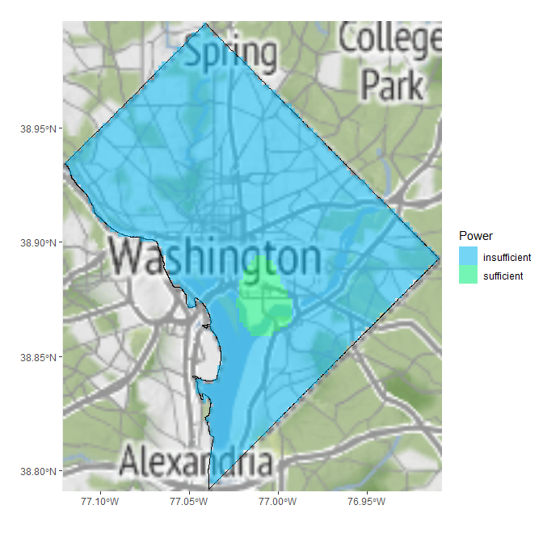

```r
pvalprop_reclass <- pvalprop_raster
values(pvalprop_reclass) <- cut(values(pvalprop_raster), c(-Inf, p_thresh, Inf))

ggmap(base_map) + # basemap
  geom_sf(
    data = dcc, # original boundary
    fill = "transparent",
    colour = "black",
    inherit.aes = FALSE
  ) +
  geom_spatraster(
    data = pvalprop_reclass, # output SpatRaster
    size = 0,
    alpha = 0.5
  ) +
  scale_fill_manual(
    values = cols[c(1,2)],
    labels = c("insufficient", "sufficient"),
    na.translate = FALSE,
    na.value = NA
  ) + # colors for SpatRaster
  labs(x = "", y = "", fill = "Power") # legend labels
```

### Advanced Features

We provide functionality to run the `spatial_power()` with parallel processing to speed up computation (`parallel = TRUE`). Parallelization is accomplished with the doFuture package, the [future::multisession](https://CRAN.R-project.org/package=future) plan, and the [%dorng%](https://CRAN.R-project.org/package=doRNG) operator for the foreach package to produce reproducible results. (Note: simpler windows, such as unit circles, require substantially less computational resources.)

We also provide functionality to correct for multiple testing. A hypothesis is tested at each gridded knot and the tests are spatially correlated by nature. With the `p_correct` argument you can choose a multiple testing correction. The most conservative, `p_correct = "Bonferroni"` and `p_correct = "Sidak"`, apply corrections that assumes independent tests, which are likely not appropriate for this setting but we include to allow for sensitivity tests. The `p_correct = "FDR"` applies a False Discovery Rate for the critical p-value that is not as conservative as the other two options.

Here, we use the same example as above, conducted in parallel with a False Discovery Rate procedure.

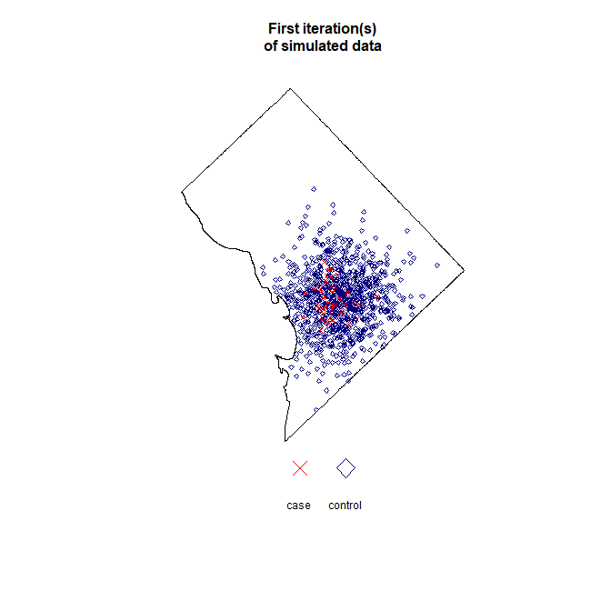

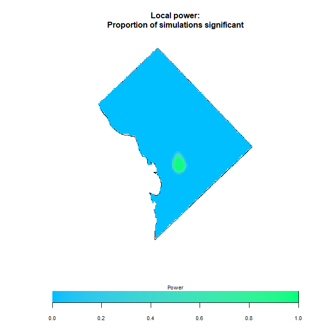

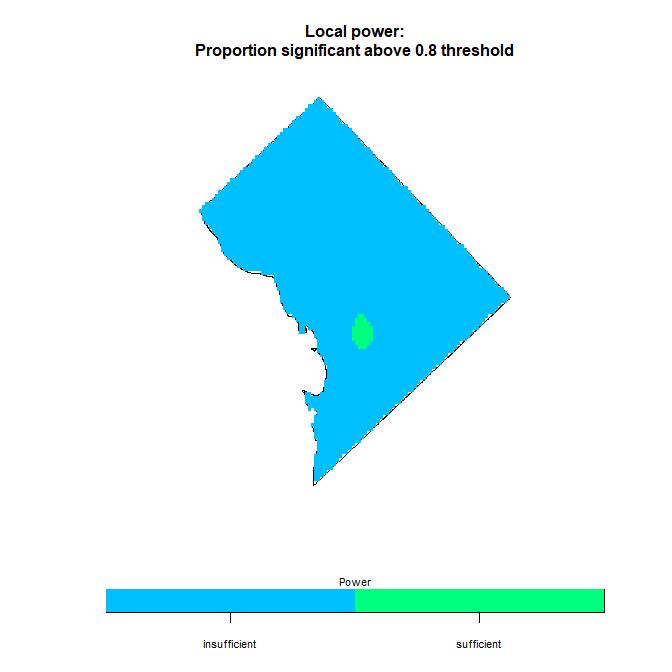

```r
set.seed(1234) # reset RNG for reproducibility with previous run
start_time <- Sys.time() # record start time
sim_power <- spatial_power(
  x_case = navy[[1]], y_case = navy[[2]], # center of cluster
  x_control = navy[[1]], y_control = navy[[2]], # center of cluster
  n_case = 50, n_control = 950, # sample size of case/control
  samp_case = "MVN", samp_control = "MVN", # samplers
  s_case = 1000, s_control = 2000, # approximate size of clusters
  alpha = 0.05, # critical p-value
  sim_total = 100, # number of iterations
  win = dco, # study area
  resolution = 100, # number gridded knots on x-axis
  edge = "diggle", # correct for edge effects
  adapt = FALSE, # fixed-bandwidth
  h0 = NULL, # automatically select bandwidth for each iteration
  verbose = FALSE, # no printout
  parallel = TRUE, # Run in parallel
  n_core = 5, # Use 5 cores (depends on your system, default = 2)
  p_correct = "FDR" # use a correction for multiple testing (False Discovery Rate)
)
end_time <- Sys.time() # record end time
time_srr <- end_time - start_time # Calculate run time

cols <- c("deepskyblue", "springgreen", "red", "navyblue") # colors for plots
chars <- c(4,5) # symbols for point-locations
sizes <- c(0.5,0.5) # size of point-locations
p_thresh <- 0.8 # 80% of iterations with statistically significant results

## Data Visualization of Input and Power
spatial_plots(
  input = sim_power, # use output of above simulation
  p_thresh = p_thresh, # power cut-off
  cascon = FALSE, # one-tail, lower tail hypothesis test (i.e., case clustering)
  plot_pts = FALSE, # display the points in the second plot
  chars = chars, # case, control
  sizes = sizes, # case, control
  cols = cols # colors of plot
)
```